# Working-with-WDI-Exercises slides

```python
# Basic Packages
from __future__ import division
import os
from datetime import datetime

# Web & file access
import requests
import io

# Import display options for showing websites
from IPython.display import IFrame, HTML
```

```python
# Plotting
import matplotlib as mpl
import matplotlib.pyplot as plt
import matplotlib.ticker as mtick

%pylab --no-import-all
%matplotlib inline

import seaborn as sns
sns.set(rc={'figure.figsize':(11.7,8.27)})
sns.set_context("talk")

import plotly.express as px
import plotly.graph_objects as go

from plotnine import ggplot, geom_point, aes, stat_smooth, facet_wrap
# Next line can import all of plotnine, but may overwrite things? Better import each function/object you need
#from plotnine import *
```

```
Using matplotlib backend: <object object at 0x13f0aef80>
%pylab is deprecated, use %matplotlib inline and import the required libraries.
```

```python
# Data
import pandas as pd
import numpy as np
from pandas_datareader import data, wb

# GIS & maps
import geopandas as gpd
gp = gpd
#import georasters as gr
#import geoplot as gplt
#import geoplot.crs as gcrs
#import mapclassify as mc
import textwrap
```

```python
# Data Munging
from itertools import product, combinations
import difflib
import pycountry
import geocoder
from geonamescache.mappers import country
mapper = country(from_key='name', to_key='iso3')
mapper2 = country(from_key='iso3', to_key='iso')
mapper3 = country(from_key='iso3', to_key='name')

# Regressions & Stats
from scipy.stats import norm
import statsmodels.formula.api as smf
from stargazer.stargazer import Stargazer, LineLocation
```

```python
# Paths
pathout = './data/'

if not os.path.exists(pathout):
    os.mkdir(pathout)

pathgraphs = './graphs/'
if not os.path.exists(pathgraphs):
    os.mkdir(pathgraphs)
```

```python
currentYear = datetime.now().year
year = min(2020, currentYear-2)
```

**Exercise 1:** Get WDI data on **patent applications by residents and non-residents in each country**. Create a new variable that shows the total patents for each country.

```python
url = 'https://pandas-datareader.readthedocs.io/en/latest/remote_data.html#remote-data-wb'
IFrame(url, width=800, height=400)
```

[interactive chart not shown]

```python
wbcountries = wb.get_countries()
wbcountries = wbcountries.loc[wbcountries.region.isin(['Aggregates'])==False].reset_index(drop=True)
wbcountries['name'] = wbcountries.name.str.strip()
wbcountries['incomeLevel'] = wbcountries['incomeLevel'].str.title()
wbcountries.loc[wbcountries.iso3c=='VEN', 'incomeLevel'] = 'Upper Middle Income'
```

```python
wdi_indicators = ['IP.PAT.NRES', 'IP.PAT.RESD', 'NY.GDP.PCAP.CD']
```

```python
wdi = wb.download(indicator=wdi_indicators, country=wbcountries.iso2c.values, start=1950, end=year)
wdi = wdi.reset_index()
wdi['year'] = wdi.year.astype(int)
wdi['nres_pat'] = wdi['IP.PAT.NRES']
wdi['ln_nres_pat'] = wdi['IP.PAT.NRES'].apply(np.log)
wdi['resd_pat'] = wdi['IP.PAT.RESD']
wdi['ln_resd_pat'] = wdi['IP.PAT.RESD'].apply(np.log)
wdi['total_pat'] = wdi['IP.PAT.NRES'] + wdi['IP.PAT.RESD']
wdi['ln_total_pat'] = wdi['IP.PAT.NRES'] + wdi['IP.PAT.RESD'].apply(np.log)
wdi['gdp_pc'] = wdi['NY.GDP.PCAP.CD']
wdi['ln_gdp_pc'] = wdi['NY.GDP.PCAP.CD'].apply(np.log)
wdi.head()
```

|  | country | year | IP.PAT.NRES | IP.PAT.RESD | NY.GDP.PCAP.CD | nres_pat | ln_nres_pat | resd_pat | ln_resd_pat | total_pat | ln_total_pat | gdp_pc | ln_gdp_pc |
| --- | --- | --- | --- | --- | --- | --- | --- | --- | --- | --- | --- | --- | --- |
| 0 | Aruba | 2020 | NaN | NaN | 23384.298791 | NaN | NaN | NaN | NaN | NaN | NaN | 23384.298791 | 10.059820 |
| 1 | Aruba | 2019 | NaN | NaN | 31135.884356 | NaN | NaN | NaN | NaN | NaN | NaN | 31135.884356 | 10.346116 |
| 2 | Aruba | 2018 | NaN | NaN | 30253.714235 | NaN | NaN | NaN | NaN | NaN | NaN | 30253.714235 | 10.317374 |
| 3 | Aruba | 2017 | NaN | NaN | 29348.418969 | NaN | NaN | NaN | NaN | NaN | NaN | 29348.418969 | 10.286994 |
| 4 | Aruba | 2016 | NaN | NaN | 28453.715565 | NaN | NaN | NaN | NaN | NaN | NaN | 28453.715565 | 10.256034 |

```python
wdi = wbcountries.merge(wdi, left_on='name', right_on='country')
wdi.head()
```

|  | iso3c | iso2c | name | region | adminregion | incomeLevel | lendingType | capitalCity | longitude | latitude | ... | IP.PAT.RESD | NY.GDP.PCAP.CD | nres_pat | ln_nres_pat | resd_pat | ln_resd_pat | total_pat | ln_total_pat | gdp_pc | ln_gdp_pc |
| --- | --- | --- | --- | --- | --- | --- | --- | --- | --- | --- | --- | --- | --- | --- | --- | --- | --- | --- | --- | --- | --- |
| 0 | ABW | AW | Aruba | Latin America & Caribbean |  | High Income | Not classified | Oranjestad | -70.0167 | 12.5167 | ... | NaN | 23384.298791 | NaN | NaN | NaN | NaN | NaN | NaN | 23384.298791 | 10.059820 |
| 1 | ABW | AW | Aruba | Latin America & Caribbean |  | High Income | Not classified | Oranjestad | -70.0167 | 12.5167 | ... | NaN | 31135.884356 | NaN | NaN | NaN | NaN | NaN | NaN | 31135.884356 | 10.346116 |
| 2 | ABW | AW | Aruba | Latin America & Caribbean |  | High Income | Not classified | Oranjestad | -70.0167 | 12.5167 | ... | NaN | 30253.714235 | NaN | NaN | NaN | NaN | NaN | NaN | 30253.714235 | 10.317374 |
| 3 | ABW | AW | Aruba | Latin America & Caribbean |  | High Income | Not classified | Oranjestad | -70.0167 | 12.5167 | ... | NaN | 29348.418969 | NaN | NaN | NaN | NaN | NaN | NaN | 29348.418969 | 10.286994 |
| 4 | ABW | AW | Aruba | Latin America & Caribbean |  | High Income | Not classified | Oranjestad | -70.0167 | 12.5167 | ... | NaN | 28453.715565 | NaN | NaN | NaN | NaN | NaN | NaN | 28453.715565 | 10.256034 |

5 rows × 23 columns

**Exercise 2:** Using the `my_xy_plot` function plot the relation between **GDP per capita** and **total patents** in the years 1990, 1995, 2000, 2010, 2020.

```python
def my_xy_plot(dfin,
               x='SP.POP.GROW',
               y='ln_gdp_pc',
               labelvar='iso3c',
               dx=0.006125,
               dy=0.006125,
               xlogscale=False,
               ylogscale=False,
               xlabel='Growth Rate of Population',
               ylabel='Log[Income per capita in ' +  str(year) + ']',
               labels=False,
               xpct = False,
               ypct = False,
               OLS=False,
               OLSlinelabel='OLS',
               ssline=False,
               sslinelabel='45 Degree Line',
               filename='income-pop-growth.pdf',
               hue='region',
               hue_order=['East Asia & Pacific', 'Europe & Central Asia',
                          'Latin America & Caribbean ', 'Middle East & North Africa',
                          'North America', 'South Asia', 'Sub-Saharan Africa '],
               style='incomeLevel',
               style_order=['High Income', 'Upper Middle Income', 'Lower Middle Income', 'Low Income'],
               palette=None,
               size=None,
               sizes=None,
               legend_fontsize=10,
               label_font_size=12,
               save=True):
    '''
    Plot the association between x and var in dataframe using labelvar for labels.
    '''
    sns.set(rc={'figure.figsize':(11.7,8.27)})
    sns.set_context("talk")
    df = dfin.copy()
    df = df.dropna(subset=[x, y]).reset_index(drop=True)
    # Plot
    k = 0
    fig, ax = plt.subplots()
    sns.scatterplot(x=x, y=y, data=df, ax=ax,
                    hue=hue,
                    hue_order=hue_order,
                    #hue='incomeLevel',
                    #hue_order=['High Income', 'Upper Middle Income', 'Lower Middle Income', 'Low Income'],
                    #hue_order=['East Asia & Pacific', 'Europe & Central Asia',
                    #           'Latin America & Caribbean ', 'Middle East & North Africa',
                    #           'North America', 'South Asia', 'Sub-Saharan Africa '],
                    alpha=1,
                    style=style,
                    style_order=style_order,
                    palette=palette,
                    size=size,
                    sizes=sizes,
                    #palette=sns.color_palette("Blues_r", df[hue].unique().shape[0]+6)[:df[hue].unique().shape[0]*2:2],
                )
    if OLS:
        sns.regplot(x=x, y=y, data=df, ax=ax, label=OLSlinelabel, scatter=False)
    if ssline:
        ax.plot([df[x].min()*.99, df[x].max()*1.01], [df[x].min()*.99, df[x].max()*1.01], c='r', label=sslinelabel)
    if labels:
        movex = df[x].mean() * dx
        movey = df[y].mean() * dy
        for line in range(0,df.shape[0]):
            ax.text(df[x][line]+movex, df[y][line]+movey, df[labelvar][line], horizontalalignment='left', fontsize=label_font_size, color='black')
    ax.set_xlabel(xlabel)
    ax.set_ylabel(ylabel)
    if xpct:
        fmt = '%.0f%%' # Format you want the ticks, e.g. '40%'
        xticks = mtick.FormatStrFormatter(fmt)
        ax.xaxis.set_major_formatter(xticks)
    if ypct:
        fmt = '%.0f%%' # Format you want the ticks, e.g. '40%'
        yticks = mtick.FormatStrFormatter(fmt)
        ax.yaxis.set_major_formatter(yticks)
    if ylogscale:
        ax.set(yscale="log")
    if xlogscale:
        ax.set(xscale="log")
    handles, labels = ax.get_legend_handles_labels()
    handles = np.array(handles)
    labels = np.array(labels)
    handles = list(handles[(labels!=hue) & (labels!=style) & (labels!=size)])
    labels = list(labels[(labels!=hue) & (labels!=style) & (labels!=size)])
    ax.legend(handles=handles, labels=labels, fontsize=legend_fontsize)
    if save:
        plt.savefig(pathgraphs + filename, dpi=300, bbox_inches='tight')
    return fig
```

```python
dffig = wdi.loc[wdi.year==year]\
            .dropna(subset=['gdp_pc', 'total_pat'])\
            .sort_values(by='region').reset_index()
```

```python
dffig1 = wdi.loc[wdi.year==2010]\
            .dropna(subset=['gdp_pc', 'total_pat'])\
            .sort_values(by='region').reset_index()
```

```python
dffig2 = wdi.loc[wdi.year==2000]\
            .dropna(subset=['gdp_pc', 'total_pat'])\
            .sort_values(by='region').reset_index()
```

```python
dffig3 = wdi.loc[wdi.year==1995]\
            .dropna(subset=['gdp_pc', 'total_pat'])\
            .sort_values(by='region').reset_index()
```

```python
dffig4 = wdi.loc[wdi.year==1990]\
            .dropna(subset=['gdp_pc', 'total_pat'])\
            .sort_values(by='region').reset_index()
```

```python
g = my_xy_plot(dffig4,
               x='gdp_pc',
               y='total_pat',
               xlabel='GDP per capita 1990',
               ylabel='Total Patents 1990',
               OLS=True,
               labels=True,
               #size="ln_pop",
               #sizes=(10, 400),
               filename='gdp_pc_total_pat_1990.pdf')
```

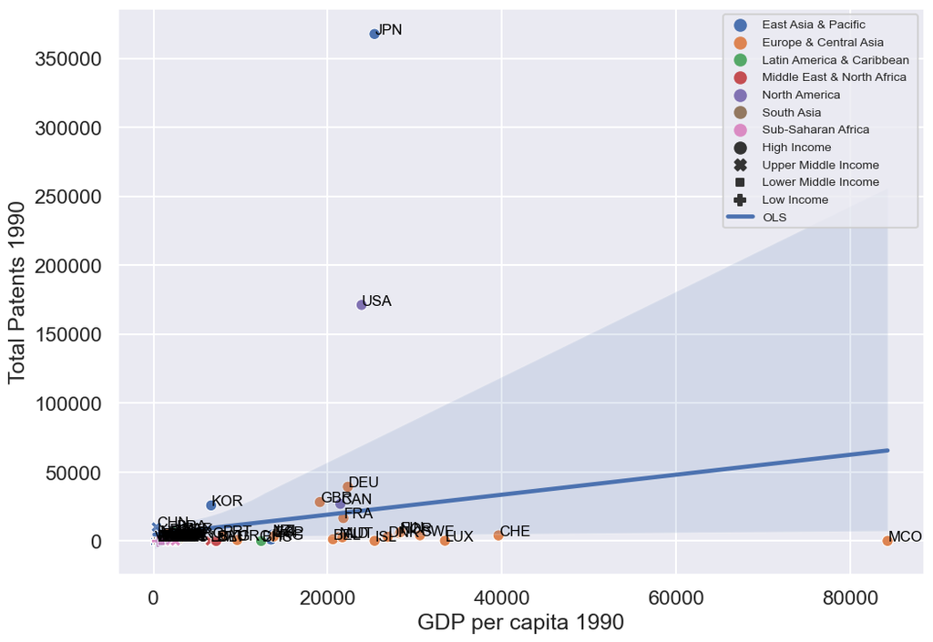

```python
g1 = my_xy_plot(dffig3,
               x='gdp_pc',
               y='total_pat',
               xlabel='GDP per capita 1995',
               ylabel='Total Patents 1995',
               OLS=True,
               labels=True,
               #size="ln_pop",
               #sizes=(10, 400),
               filename='gdp_pc_total_pat_1995.pdf')
```

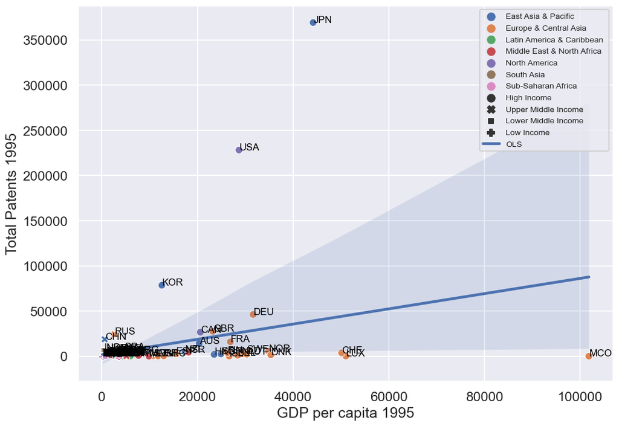

```python
g2 = my_xy_plot(dffig2,
               x='gdp_pc',
               y='total_pat',
               xlabel='GDP per capita 2000',
               ylabel='Total Patents 2000',
               OLS=True,
               labels=True,
               #size="ln_pop",
               #sizes=(10, 400),
               filename='gdp_pc_total_pat_2000.pdf')
```

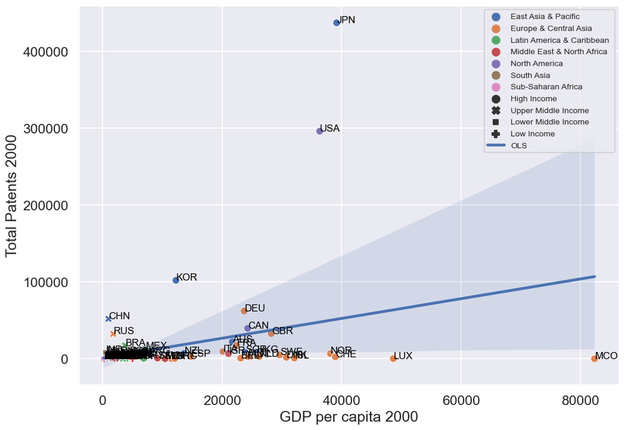

```python
g3 = my_xy_plot(dffig1,
               x='gdp_pc',
               y='total_pat',
               xlabel='GDP per capita 2010',
               ylabel='Total Patents 2010',
               OLS=True,
               labels=True,
               #size="ln_pop",
               #sizes=(10, 400),
               filename='gdp_pc_total_pat_2010.pdf')
```

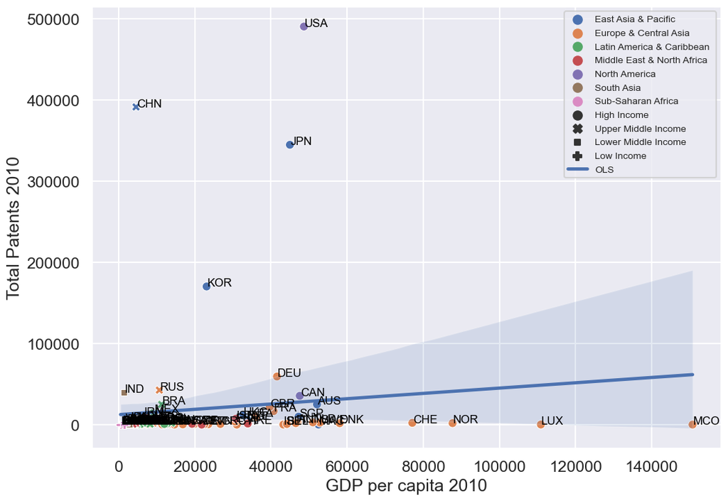

```python
g4 = my_xy_plot(dffig,
               x='gdp_pc',
               y='total_pat',
               xlabel='GDP per capita 2020',
               ylabel='Total Patents 2020',
               OLS=True,
               labels=True,
               #size="ln_pop",
               #sizes=(10, 400),
               filename='gdp_pc_total_pat_2020.pdf')
```

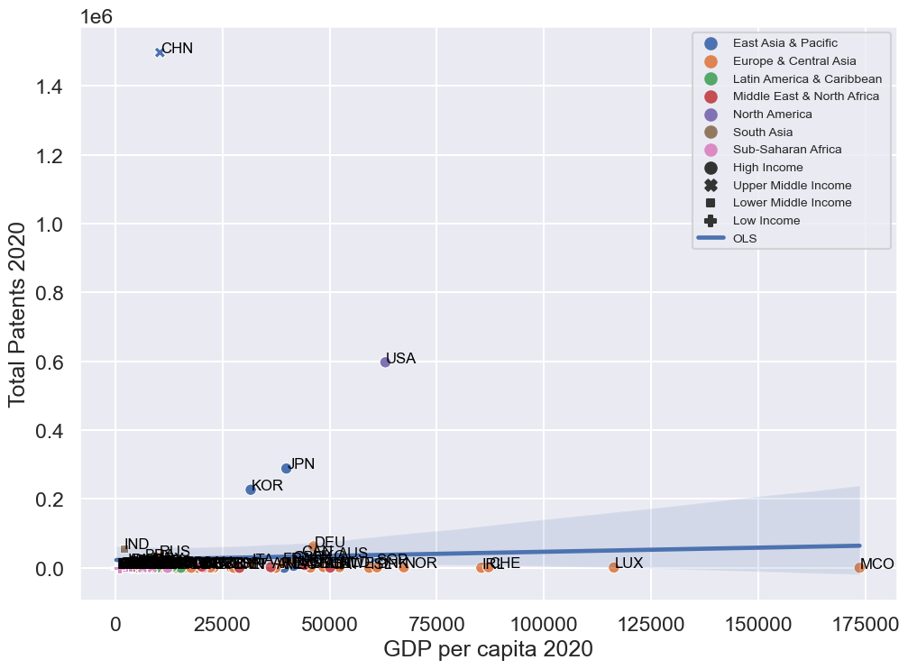

**Exercise 3:** Using the `my_xy_line_plot` function plot the evolution of **GDP per capita** and **total patents** by income groups and regions (separate figures).

```python
def my_xy_line_plot(dfin,
                    x='year',
                    y='ln_gdp_pc',
                    labelvar='iso3c',
                    dx=0.006125,
                    dy=0.006125,
                    xlogscale=False,
                    ylogscale=False,
                    xlabel='Growth Rate of Population',
                    ylabel='Log[Income per capita in ' +  str(year) + ']',
                    labels=False,
                    xpct = False,
                    ypct = False,
                    OLS=False,
                    OLSlinelabel='OLS',
                    ssline=False,
                    sslinelabel='45 Degree Line',
                    filename='income-pop-growth.pdf',
                    hue='region',
                    hue_order=['East Asia & Pacific', 'Europe & Central Asia',
                               'Latin America & Caribbean ', 'Middle East & North Africa',
                               'North America', 'South Asia', 'Sub-Saharan Africa '],
                    style='incomeLevel',
                    style_order=['High Income', 'Upper Middle Income', 'Lower Middle Income', 'Low Income'],
                    palette=None,
                    legend_fontsize=10,
                    label_fontsize=12,
                    loc=None,
                    save=True):
    '''
    Plot the association between x and var in dataframe using labelvar for labels.
    '''
    sns.set(rc={'figure.figsize':(11.7,8.27)})
    sns.set_context("talk")
    df = dfin.copy()
    df = df.dropna(subset=[x, y]).reset_index(drop=True)
    # Plot
    k = 0
    fig, ax = plt.subplots()
    sns.lineplot(x=x, y=y, data=df, ax=ax,
                    hue=hue,
                    hue_order=hue_order,
                    alpha=1,
                    style=style,
                    style_order=style_order,
                    palette=palette,
                )
    if OLS:
        sns.regplot(x=x, y=y, data=df, ax=ax, label=OLSlinelabel, scatter=False)
    if ssline:
        ax.plot([df[x].min()*.99, df[x].max()*1.01], [df[x].min()*.99, df[x].max()*1.01], c='r', label=sslinelabel)
    if labels:
        movex = df[x].mean() * dx
        movey = df[y].mean() * dy
        for line in range(0,df.shape[0]):
            ax.text(df[x][line]+movex, df[y][line]+movey, df[labelvar][line], horizontalalignment='left', fontsize=label_fontsize, color='black')
    ax.set_xlabel(xlabel)
    ax.set_ylabel(ylabel)
    if xpct:
        fmt = '%.0f%%' # Format you want the ticks, e.g. '40%'
        xticks = mtick.FormatStrFormatter(fmt)
        ax.xaxis.set_major_formatter(xticks)
    if ypct:
        fmt = '%.0f%%' # Format you want the ticks, e.g. '40%'
        yticks = mtick.FormatStrFormatter(fmt)
        ax.yaxis.set_major_formatter(yticks)
    if ylogscale:
        ax.set(yscale="log")
    if xlogscale:
        ax.set(xscale="log")
    handles, labels = ax.get_legend_handles_labels()
    handles = np.array(handles)
    labels = np.array(labels)
    handles = list(handles[(labels!='region') & (labels!='incomeLevel')])
    labels = list(labels[(labels!='region') & (labels!='incomeLevel')])
    ax.legend(handles=handles, labels=labels, fontsize=legend_fontsize, loc=loc)
    if save:
        plt.savefig(pathgraphs + filename, dpi=300, bbox_inches='tight')
    return fig
```